# New Zealand Spatial Features

The `nzsf` package relies heavily on the R packages `ggplot2`, `dplyr`, and `sf`. Maps can be built up in layers in the same way as `ggplot2`.

```r
# devtools::install_github(repo = "ropensci/rnaturalearthhires")
# library(rnaturalearthhires) # required for scale = "large" in ne_countries
library(rnaturalearth)
library(rnaturalearthdata)

library(nzsf)
library(tidyverse)
library(ggspatial)
library(viridis)
library(raster)
library(lwgeom)
library(patchwork)
library(stars)
library(ggnewscale)

theme_set(theme_bw() + theme(axis.title = element_blank()))
```

# CCAMLR

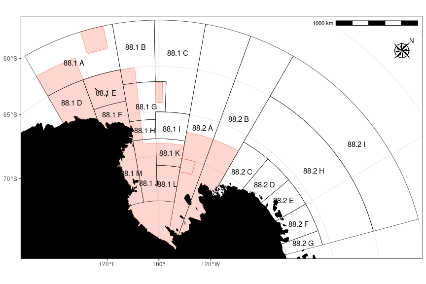

```r
ggplot() +
  geom_ccamlr("mpa", fill = "tomato", colour = "tomato", alpha = 0.25) +
  geom_ccamlr("ssru") +
  geom_ccamlr("land", fill = "black") +
  geom_ccamlr("label") +
  annotation_north_arrow(location = "tr", which_north = "true",
                         style = north_arrow_nautical, pad_y = unit(1, "cm")) +
  annotation_scale(location = "tr", unit_category = "metric") +
  coord_ccamlr()
```

# CCSBT

The `nzsf` package also includes functions for plotting CCSBT management areas. In the example below I simulate 100 points, generate a voronoi diagram around these points, then simulate values at 5000 points and sum the values of these points within the voronoi polygons:

```r
CCSBT3994 <- CCSBT %>% st_transform(proj_ccsbt()) %>%
  st_union(by_feature = TRUE)

# Simulate some points within the areas
pts1 <- st_sample(CCSBT3994, size = 100) %>% st_sf()
pts2 <- st_sample(CCSBT3994, size = 5000) %>% st_sf() %>%
  mutate(z = rnorm(1:n()))

# Sum up points within voronoi polygons
vri <- pts1 %>%
  st_union() %>%
  st_voronoi(envelope = NULL) %>%
  st_collection_extract() %>%
  st_cast() %>%
  st_sf() %>%
  mutate(id = 1:n()) %>%
  st_join(pts2, join = st_contains, left = TRUE) %>%
  group_by(id) %>%
  summarise(z = sum(z)) %>%
  st_intersection(CCSBT3994)
```

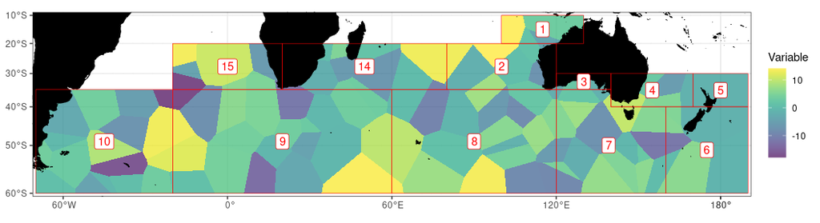

```r
ggplot() +
  geom_sf(data = vri, aes(fill = z), colour = NA) +
  scale_fill_viridis("Variable", alpha = 0.7, na.value = NA) +
  # plot_depth(proj = 3994) +
  geom_ccsbt("land", fill = "black", colour = "black") +
  geom_ccsbt("area", colour = "red") +
  geom_ccsbt("label", fill = "white", colour = "red") +
  coord_ccsbt()
```

# SPRFMO

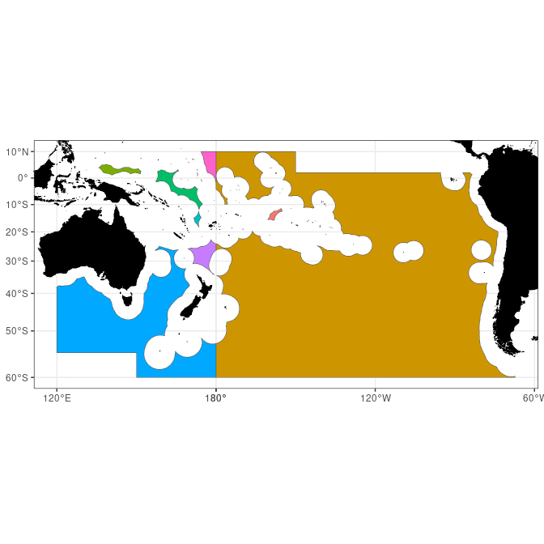

```r
SPRFMO3832 <- SPRFMO %>% st_transform(crs = 3832)

world <- ne_countries(scale = "medium", returnclass = "sf") %>%
  st_transform(crs = 3832)

ggplot() +
  geom_sf(data = world, fill = "black", colour = "black") +
  geom_sf(data = SPRFMO3832, aes(fill = factor(OBJECTID))) +
  coord_sf() +
  plot_clip(SPRFMO3832) +
  theme_bw() +
  theme(legend.position = "none")
```

# SIOFA

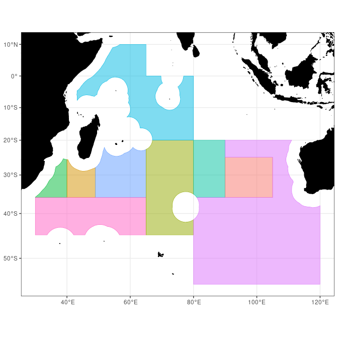

```r
SIOFA3832 <- SIOFA %>% st_transform(crs = 3832)

ggplot() +
  # geom_gebco(proj = 3832, downsample = 3) +
  # geom_stars(data = bathy, downsample = 3) +
  geom_sf(data = world, fill = "black", colour = "black") +
  new_scale("fill") +
  geom_sf(data = SIOFA3832, alpha = 0.5,
          aes(fill = factor(SubArea), colour = factor(SubArea))) +
  plot_clip(SIOFA3832) +
  theme_bw() +
  theme(legend.position = "none")
```

# New Zealand

Compare a plot of low resolution coastline to the `rnaturalearth` package.

```r
nz <- ne_countries(scale = "medium", country = "New Zealand",
                   returnclass = "sf") %>%
  st_transform(crs = proj_nzsf()) %>%
  st_crop(get_statistical_areas(area = "EEZ"))
```

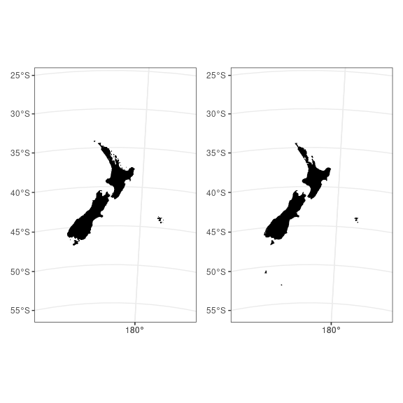

```r
p1 <- ggplot() +
  plot_coast(resolution = "1250k", fill = "black", colour = "black") +
  plot_clip(x = "NZ")
p2 <- ggplot() +
  geom_sf(data = nz, fill = "black", colour = "black") +
  plot_clip(x = "NZ")

p1 + p2
```

An example that aggregates spatial features

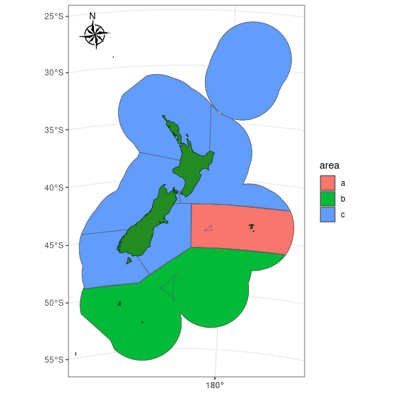

```r
aa <- nz_general_statistical_areas %>%
  dplyr::select(Statistica) %>%
  st_transform(crs = proj_nzsf()) %>%
  st_union(by_feature = TRUE) %>%
  mutate(area = case_when(
    Statistica %in% c(401:412, "049", "050", "051", "052") ~ "a",
    Statistica %in% 601:625 ~ "b",
    TRUE ~ as.character("c")
  )) %>%
  group_by(area) %>%
  summarize(geometry = st_union(geometry))

ggplot() +
  geom_sf(data = aa, aes(fill = area)) +
  plot_qma(qma = "LIN", fill = "transparent") +
  # plot_statistical_areas(area = "stat area", fill = "transparent") +
  plot_coast(resolution = "med", fill = "forestgreen", colour = "black") +
  plot_clip("NZ") +
  annotation_north_arrow(location = "tl", which_north = "true",
                         style = north_arrow_nautical)
```

Layers such as New Zealand marine reserves, depth countours, and Quota Management Areas (QMAs) can be added easily with several of the `nzsf` helper functions including `plot_marine_reserves`, `plot_depth`, and `plot_qma`. Maps can be restricted (e.g. to the North Island only) using a bounding box generated using `st_bbox` from the `sf` package:

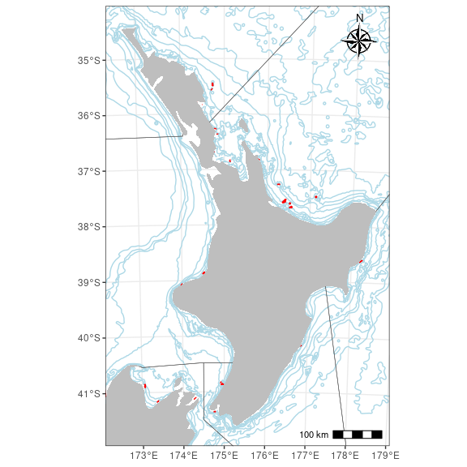

```r
# bbox <- get_coast() %>%
bbox <- nzsf::nz_coastlines_and_islands_polygons_topo_1500k %>%
  st_transform(crs = proj_nzsf()) %>%
  filter(name %in% c("North Island or Te Ika-a-Māui")) %>%
  st_bbox()

ggplot() +
  plot_depth(colour = "lightblue") +
  plot_marine_reserves(fill = "red", colour = "red") +
  plot_qma(qma = "CRA", fill = NA) +
  plot_coast(resolution = "medium", fill = "grey", colour = NA) +
  coord_sf(xlim = bbox[c(1, 3)], ylim = bbox[c(2, 4)]) +
  annotation_north_arrow(location = "tr", which_north = "true",
                         style = north_arrow_nautical) +
  annotation_scale(location = "br", unit_category = "metric")
```

Adding labels can be done with:

```r
sf_jma <- get_qma("JMA")
sf_coast <- get_coast() %>% st_combine() %>% st_make_valid()
lab <- st_difference(sf_jma, sf_coast) %>% st_point_on_surface()
```

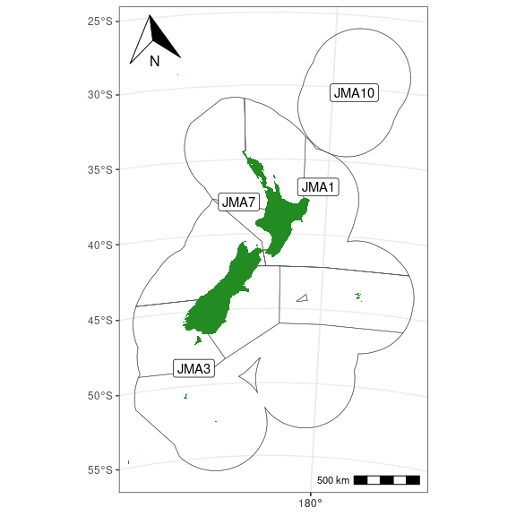

```r
# lab <- st_difference(sf_jma, sf_coast) %>% st_centroid()

ggplot() +
  plot_qma(qma = "JMA", fill = NA) +
  plot_statistical_areas(area = "JMA", fill = NA) +
  plot_coast(fill = "forestgreen", colour = NA) +
  geom_sf_label(data = lab, aes(label = QMA)) +
  plot_clip(x = "NZ") +
  annotation_north_arrow(location = "tl", which_north = "true") +
  annotation_scale(location = "br", unit_category = "metric")
```

You can then add polygons, points, lines/arrows, and/or rasters to maps and change the map projection:

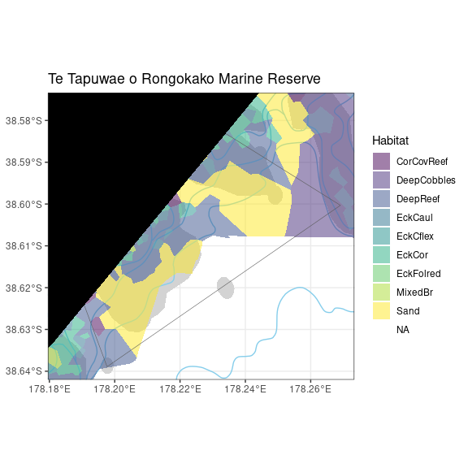

```r
proj <- "+proj=longlat +datum=WGS84 +no_defs"

data("Gisborne_TToR_Habitats")
Gisborne_TToR_Habitats <- Gisborne_TToR_Habitats %>%
  st_transform(crs = proj, check = TRUE)

data("Rocky_reef_National_NZ")
Rocky_reef_National_NZ <- Rocky_reef_National_NZ %>%
  st_transform(crs = proj, check = TRUE)

bbox <- get_marine_reserves() %>%
  st_transform(crs = proj, check = TRUE) %>%
  filter(Name == "Te Tapuwae o Rongokako Marine Reserve") %>%
  st_bbox()

ggplot() +
  geom_sf(data = Rocky_reef_National_NZ, fill = "lightgrey", colour = NA) +
  plot_depth(proj = proj, resolution = "med", size = 0.2, colour = "skyblue") +
  geom_sf(data = Gisborne_TToR_Habitats, aes(fill = Habitat), colour = NA) +
  scale_fill_viridis_d(alpha = 0.5) +
  plot_marine_reserves(proj = proj, fill = NA) +
  plot_coast(proj = proj, resolution = "med", fill = "black", colour = NA) +
  coord_sf(xlim = bbox[c(1, 3)], ylim = bbox[c(2, 4)]) +
  labs(title = "Te Tapuwae o Rongokako Marine Reserve")
```

Simulate some points around Stewart Island.

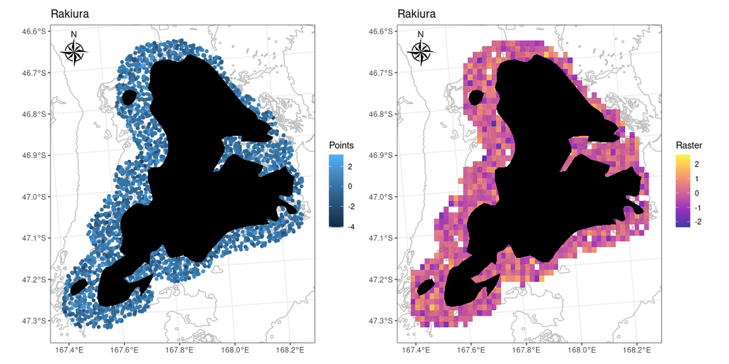

```r
# stewart <- get_coast() %>%
stewart <- nzsf::nz_coastlines_and_islands_polygons_topo_1500k %>%
  filter(name == "Stewart Island/Rakiura") %>%
  st_transform(crs = proj_nzsf()) %>%
  st_buffer(dist = 4500)

pts <- st_sample(stewart, size = 5000) %>%
  st_sf() %>%
  mutate(z = rnorm(1:n()))

p1 <- ggplot() +
  plot_depth(resolution = "med", size = 0.2, colour = "grey") +
  geom_sf(data = pts, aes(colour = z)) +
  plot_coast(resolution = "large", fill = "black", colour = NA) +
  annotation_north_arrow(location = "tl", style = north_arrow_nautical) +
  plot_clip(x = stewart) +
  labs(colour = "Points", title = "Rakiura")

p2 <- ggplot() +
  plot_depth(resolution = "med", size = 0.2, colour = "grey") +
  plot_raster(data = pts, field = "z", fun = mean, nrow = 50, ncol = 50) +
  scale_fill_viridis("Raster", alpha = 0.8, option = "plasma") +
  plot_coast(resolution = "large", fill = "black", colour = NA) +
  annotation_north_arrow(location = "tl", style = north_arrow_nautical) +
  plot_clip(x = stewart) +
  labs(title = "Rakiura")

p1 + p2
```

```r
eez <- get_statistical_areas("EEZ", proj = 4326) %>% st_shift_longitude()

r <- get_standard_grid(cell_size = 1/1000, bounding_box = st_bbox(eez),
                       return_raster = FALSE, crs = 4326)
```

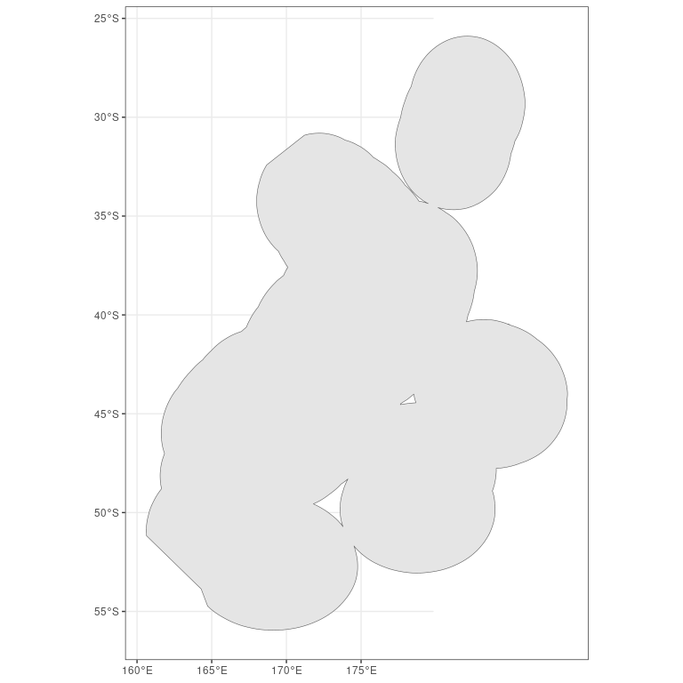

```r
ggplot(data = eez) + geom_sf()
```

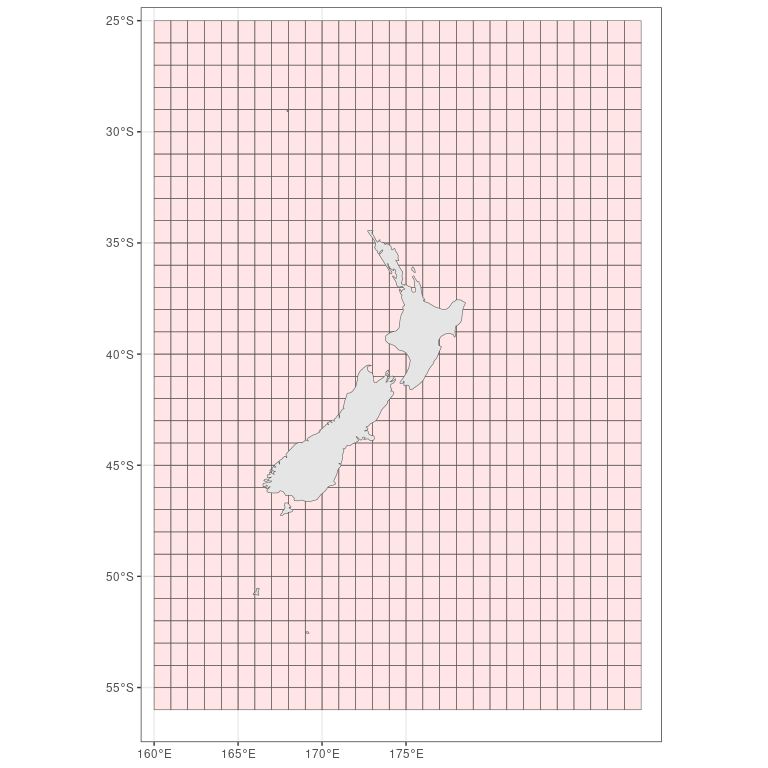

```r
ggplot(data = r) +
  geom_sf(fill = "red", alpha = 0.1) +
  plot_coast(proj = 4326) +
  plot_clip(eez, proj = 4326) +
  theme_bw()
```